# Introduction

While on Kaggle I stumbled upon an interesting dataset. The data was created because Netflix has a quantity over quality problem with their content. For those not familiar with Netflix, they are an American subscription video on-demand over-the-top streaming service. The service primarily distributes original and acquired films and television shows from various genres, and it is available internationally in multiple languages.

With this dataset I asked myself 4 questions and used EDA to help me get a better understanding of the problem. My questions are as follows:

1. When we open Netflix we see that they are mainly two categories which are movies or series. Which category is more popular?
2. What are the popular genres in movies and series?
3. The most watched languages?
4. The most popular TV Series and Movies from IMDb and Rotten Tomatoes?

For the analysis of the data, I used the following libraries:

1. pandas
2. numpy
3. seaborn
4. matplotlib

```python
import pandas as pd
import numpy as np
import seaborn as sns
import matplotlib.pyplot as plot

print("Setup complete")
```

```
Setup complete
```

```python
file_path = 'netflix-rotten-tomatoes-metacritic-imdb.csv'
data = pd.read_csv(file_path)
df = data.copy()
print("The data has been loaded and this is a preview of it!")
df.head()
```

```
The data has been loaded and this is a preview of it!
```

|  | Title | Genre | Tags | Languages | Series or Movie | Hidden Gem Score | Country Availability | Runtime | Director | Writer | ... | Netflix Release Date | Production House | Netflix Link | IMDb Link | Summary | IMDb Votes | Image | Poster | TMDb Trailer | Trailer Site |
| --- | --- | --- | --- | --- | --- | --- | --- | --- | --- | --- | --- | --- | --- | --- | --- | --- | --- | --- | --- | --- | --- |
| 0 | Lets Fight Ghost | Crime, Drama, Fantasy, Horror, Romance | Comedy Programmes,Romantic TV Comedies,Horror ... | Swedish, Spanish | Series | 4.3 | Thailand | < 30 minutes | Tomas Alfredson | John Ajvide Lindqvist | ... | 2021-03-04 | Canal+, Sandrew Metronome | https://www.netflix.com/watch/81415947 | https://www.imdb.com/title/tt1139797 | A med student with a supernatural gift tries t... | 205926.0 | https://occ-0-4708-64.1.nflxso.net/dnm/api/v6/... | https://m.media-amazon.com/images/M/MV5BOWM4NT... | NaN | NaN |
| 1 | HOW TO BUILD A GIRL | Comedy | Dramas,Comedies,Films Based on Books,British | English | Movie | 7.0 | Canada | 1-2 hour | Coky Giedroyc | Caitlin Moran | ... | 2021-03-04 | Film 4, Monumental Pictures, Lionsgate | https://www.netflix.com/watch/81041267 | https://www.imdb.com/title/tt4193072 | When nerdy Johanna moves to London, things get... | 2838.0 | https://occ-0-1081-999.1.nflxso.net/dnm/api/v6... | https://m.media-amazon.com/images/M/MV5BZGUyN2... | https://www.youtube.com/watch?v=eIbcxPy4okQ | YouTube |
| 2 | Centigrade | Drama, Thriller | Thrillers | English | Movie | 6.4 | Canada | 1-2 hour | Brendan Walsh | Brendan Walsh, Daley Nixon | ... | 2021-03-04 | NaN | https://www.netflix.com/watch/81305978 | https://www.imdb.com/title/tt8945942 | Trapped in a frozen car during a blizzard, a p... | 1720.0 | https://occ-0-1081-999.1.nflxso.net/dnm/api/v6... | https://m.media-amazon.com/images/M/MV5BODM2MD... | https://www.youtube.com/watch?v=0RvV7TNUlkQ | YouTube |
| 3 | ANNE+ | Drama | TV Dramas,Romantic TV Dramas,Dutch TV Shows | Turkish | Series | 7.7 | Belgium,Netherlands | < 30 minutes | NaN | NaN | ... | 2021-03-04 | NaN | https://www.netflix.com/watch/81336456 | https://www.imdb.com/title/tt6132758 | Upon moving into a new place, a 20-something r... | 1147.0 | https://occ-0-1489-1490.1.nflxso.net/dnm/api/v... | https://m.media-amazon.com/images/M/MV5BNWRkMz... | NaN | NaN |
| 4 | Moxie | Animation, Short, Drama | Social Issue Dramas,Teen Movies,Dramas,Comedie... | English | Movie | 8.1 | Lithuania,Poland,France,Iceland,Italy,Spain,Gr... | 1-2 hour | Stephen Irwin | NaN | ... | 2021-03-04 | NaN | https://www.netflix.com/watch/81078393 | https://www.imdb.com/title/tt2023611 | Inspired by her moms rebellious past and a con... | 63.0 | https://occ-0-4039-1500.1.nflxso.net/dnm/api/v... | https://m.media-amazon.com/images/M/MV5BODYyNW... | NaN | NaN |

5 rows × 29 columns

# Data cleaning

Lets begin by observing different kinds of data

We can see this by using the .info() function

```python
df.info()
```

```
<class 'pandas.core.frame.DataFrame'>
RangeIndex: 15480 entries, 0 to 15479
Data columns (total 29 columns):
 #   Column                 Non-Null Count  Dtype
---  ------                 --------------  -----
 0   Title                  15480 non-null  object
 1   Genre                  13770 non-null  object
 2   Tags                   15413 non-null  object
 3   Languages              13526 non-null  object
 4   Series or Movie        15480 non-null  object
 5   Hidden Gem Score       13379 non-null  float64
 6   Country Availability   15461 non-null  object
 7   Runtime                15479 non-null  object
 8   Director               10772 non-null  object
 9   Writer                 11150 non-null  object
```

[output cut: 21 more lines]

Now lets check for null values

```python
df.isnull().sum()
```

```
Title                        0
Genre                     1710
Tags                        67
Languages                 1954
Series or Movie              0
Hidden Gem Score          2101
Country Availability        19
Runtime                      1
Director                  4708
Writer                    4330
Actors                    1925
View Rating               7024
IMDb Score                2099
Rotten Tomatoes Score     9098
Metacritic Score         11144
Awards Received           9405
Awards Nominated For      7819
Boxoffice                11473
Release Date              2107
Netflix Release Date         0
Production House         10331
Netflix Link                 0
IMDb Link                 2303
Summary                      9
IMDb Votes                2101
Image                        0
Poster                    3638
TMDb Trailer              8286
Trailer Site              8286
dtype: int64
```

As we saw that the dataset contains many missing values and it also has some columns that we probably do not need, hence we will be droping the columns which we do not need

```python
df = df.drop(columns = [ 'Metacritic Score', 'Boxoffice', 'Production House', 'Netflix Link', 'IMDb Link',
        'Poster', 'TMDb Trailer', 'Trailer Site'], axis = 1)
```

Lets now create another column called id

```python
n = 1
df.insert(0, 'ID', range(n, n + df.shape[0]))
```

```python
df.dropna(axis = 0, how ='any')
```

|  | ID | Title | Genre | Tags | Languages | Series or Movie | Hidden Gem Score | Country Availability | Runtime | Director | ... | View Rating | IMDb Score | Rotten Tomatoes Score | Awards Received | Awards Nominated For | Release Date | Netflix Release Date | Summary | IMDb Votes | Image |
| --- | --- | --- | --- | --- | --- | --- | --- | --- | --- | --- | --- | --- | --- | --- | --- | --- | --- | --- | --- | --- | --- |
| 0 | 1 | Lets Fight Ghost | Crime, Drama, Fantasy, Horror, Romance | Comedy Programmes,Romantic TV Comedies,Horror ... | Swedish, Spanish | Series | 4.3 | Thailand | < 30 minutes | Tomas Alfredson | ... | R | 7.9 | 98.0 | 74.0 | 57.0 | 12 Dec 2008 | 2021-03-04 | A med student with a supernatural gift tries t... | 205926.0 | https://occ-0-4708-64.1.nflxso.net/dnm/api/v6/... |
| 15 | 16 | Joker | Crime, Drama, Thriller | Dark Comedies,Crime Comedies,Dramas,Comedies,C... | English | Movie | 3.5 | Lithuania,Poland,France,Italy,Spain,Greece,Bel... | 1-2 hour | Todd Phillips | ... | R | 8.4 | 68.0 | 112.0 | 228.0 | 04 Oct 2019 | 2021-03-03 | A practical jokers fake kidnapping at a bachel... | 951938.0 | https://occ-0-2851-41.1.nflxso.net/dnm/api/v6/... |
| 16 | 17 | I | Action, Adventure, Fantasy, Sci-Fi | Dramas,Swedish Movies | English, Sanskrit | Movie | 2.8 | Lithuania,Poland,France,Italy,Spain,Greece,Cze... | 1-2 hour | George Lucas | ... | PG | 6.5 | 52.0 | 26.0 | 69.0 | 19 May 1999 | 2021-03-03 | A young man seeking his identity begins a roma... | 733336.0 | https://occ-0-2851-41.1.nflxso.net/dnm/api/v6/... |
| 17 | 18 | Harrys Daughters | Adventure, Drama, Fantasy, Mystery | Dramas,Swedish Movies | English | Movie | 4.4 | Lithuania,Poland,France,Italy,Spain,Greece,Cze... | 1-2 hour | David Yates | ... | PG-13 | 8.1 | 96.0 | 46.0 | 94.0 | 15 Jul 2011 | 2021-03-03 | As two sisters both experience pregnancy, trag... | 766594.0 | https://occ-0-2851-41.1.nflxso.net/dnm/api/v6/... |
| 28 | 29 | The Closet | Comedy | Korean Movies,Horror Movies,Mysteries | French | Movie | 3.8 | South Korea | 1-2 hour | Francis Veber | ... | R | 7.0 | 85.0 | 1.0 | 1.0 | 10 Aug 2001 | 2021-03-01 | A recent widowers move into a new house takes ... | 16657.0 | https://occ-0-395-988.1.nflxso.net/dnm/api/v6/... |
| ... | ... | ... | ... | ... | ... | ... | ... | ... | ... | ... | ... | ... | ... | ... | ... | ... | ... | ... | ... | ... | ... |
| 15459 | 15460 | One Chance | Biography, Comedy, Drama, Music | Dramas,Biographical Dramas,Dramas based on rea... | English, Italian | Movie | 3.0 | Japan,Malaysia | 1-2 hour | David Frankel | ... | PG-13 | 6.8 | 63.0 | 3.0 | 5.0 | 25 Oct 2013 | 2015-04-14 | From shop worker to worldwide phenomena, this ... | 11536.0 | https://occ-0-768-769.1.nflxso.net/dnm/api/v6/... |
| 15460 | 15461 | The Twilight Saga: Breaking Dawn: Part 1 | Adventure, Drama, Fantasy, Romance, Thriller | Dramas,Romantic Dramas,Dramas based on a book,... | English, Portuguese | Movie | 2.0 | Canada,Romania,Japan,Switzerland,United Kingdo... | > 2 hrs | Bill Condon | ... | PG-13 | 4.9 | 25.0 | 11.0 | 22.0 | 18 Nov 2011 | 2015-04-14 | Not long after immortal soul mates Bella Swan ... | 224372.0 | https://occ-0-2773-2774.1.nflxso.net/dnm/api/v... |
| 15461 | 15462 | One for the Money | Action, Comedy, Crime, Thriller | Romantic Comedies,Action Comedies,Comedies,Pol... | English | Movie | 1.3 | Canada | 1-2 hour | Julie Anne Robinson | ... | PG-13 | 5.3 | 2.0 | 1.0 | 1.0 | 27 Jan 2012 | 2015-04-14 | A divorced, unemployed woman becomes a bounty ... | 40841.0 | https://occ-0-2773-2774.1.nflxso.net/dnm/api/v... |
| 15462 | 15463 | 4.3.2.1 | Crime, Thriller | Thrillers,Steamy Thrillers,Police Thrillers,Po... | English | Movie | 2.4 | India | 1-2 hour | Mark Davis, Noel Clarke | ... | Not Rated | 5.8 | 37.0 | 1.0 | 3.0 | 02 Jun 2010 | 2015-04-14 | The clock is ticking as four young women have ... | 10370.0 | https://occ-0-2042-299.1.nflxso.net/dnm/api/v6... |
| 15463 | 15464 | 13 | Crime, Drama, Thriller | Thrillers,Gangster Films,Police Thrillers,Poli... | English | Movie | 1.6 | Romania,Hungary,Czech Republic,Slovakia | 1-2 hour | Géla Babluani | ... | R | 6.1 | 8.0 | 1.0 | 1.0 | 01 Mar 2010 | 2015-04-14 | After assuming a dead persons identity, a call... | 40425.0 | https://occ-0-2773-2774.1.nflxso.net/dnm/api/v... |

3079 rows × 22 columns

```python
df.dropna(axis = 0, how ='any')
```

|  | ID | Title | Genre | Tags | Languages | Series or Movie | Hidden Gem Score | Country Availability | Runtime | Director | ... | View Rating | IMDb Score | Rotten Tomatoes Score | Awards Received | Awards Nominated For | Release Date | Netflix Release Date | Summary | IMDb Votes | Image |
| --- | --- | --- | --- | --- | --- | --- | --- | --- | --- | --- | --- | --- | --- | --- | --- | --- | --- | --- | --- | --- | --- |
| 0 | 1 | Lets Fight Ghost | Crime, Drama, Fantasy, Horror, Romance | Comedy Programmes,Romantic TV Comedies,Horror ... | Swedish, Spanish | Series | 4.3 | Thailand | < 30 minutes | Tomas Alfredson | ... | R | 7.9 | 98.0 | 74.0 | 57.0 | 12 Dec 2008 | 2021-03-04 | A med student with a supernatural gift tries t... | 205926.0 | https://occ-0-4708-64.1.nflxso.net/dnm/api/v6/... |
| 15 | 16 | Joker | Crime, Drama, Thriller | Dark Comedies,Crime Comedies,Dramas,Comedies,C... | English | Movie | 3.5 | Lithuania,Poland,France,Italy,Spain,Greece,Bel... | 1-2 hour | Todd Phillips | ... | R | 8.4 | 68.0 | 112.0 | 228.0 | 04 Oct 2019 | 2021-03-03 | A practical jokers fake kidnapping at a bachel... | 951938.0 | https://occ-0-2851-41.1.nflxso.net/dnm/api/v6/... |
| 16 | 17 | I | Action, Adventure, Fantasy, Sci-Fi | Dramas,Swedish Movies | English, Sanskrit | Movie | 2.8 | Lithuania,Poland,France,Italy,Spain,Greece,Cze... | 1-2 hour | George Lucas | ... | PG | 6.5 | 52.0 | 26.0 | 69.0 | 19 May 1999 | 2021-03-03 | A young man seeking his identity begins a roma... | 733336.0 | https://occ-0-2851-41.1.nflxso.net/dnm/api/v6/... |
| 17 | 18 | Harrys Daughters | Adventure, Drama, Fantasy, Mystery | Dramas,Swedish Movies | English | Movie | 4.4 | Lithuania,Poland,France,Italy,Spain,Greece,Cze... | 1-2 hour | David Yates | ... | PG-13 | 8.1 | 96.0 | 46.0 | 94.0 | 15 Jul 2011 | 2021-03-03 | As two sisters both experience pregnancy, trag... | 766594.0 | https://occ-0-2851-41.1.nflxso.net/dnm/api/v6/... |
| 28 | 29 | The Closet | Comedy | Korean Movies,Horror Movies,Mysteries | French | Movie | 3.8 | South Korea | 1-2 hour | Francis Veber | ... | R | 7.0 | 85.0 | 1.0 | 1.0 | 10 Aug 2001 | 2021-03-01 | A recent widowers move into a new house takes ... | 16657.0 | https://occ-0-395-988.1.nflxso.net/dnm/api/v6/... |
| ... | ... | ... | ... | ... | ... | ... | ... | ... | ... | ... | ... | ... | ... | ... | ... | ... | ... | ... | ... | ... | ... |
| 15459 | 15460 | One Chance | Biography, Comedy, Drama, Music | Dramas,Biographical Dramas,Dramas based on rea... | English, Italian | Movie | 3.0 | Japan,Malaysia | 1-2 hour | David Frankel | ... | PG-13 | 6.8 | 63.0 | 3.0 | 5.0 | 25 Oct 2013 | 2015-04-14 | From shop worker to worldwide phenomena, this ... | 11536.0 | https://occ-0-768-769.1.nflxso.net/dnm/api/v6/... |
| 15460 | 15461 | The Twilight Saga: Breaking Dawn: Part 1 | Adventure, Drama, Fantasy, Romance, Thriller | Dramas,Romantic Dramas,Dramas based on a book,... | English, Portuguese | Movie | 2.0 | Canada,Romania,Japan,Switzerland,United Kingdo... | > 2 hrs | Bill Condon | ... | PG-13 | 4.9 | 25.0 | 11.0 | 22.0 | 18 Nov 2011 | 2015-04-14 | Not long after immortal soul mates Bella Swan ... | 224372.0 | https://occ-0-2773-2774.1.nflxso.net/dnm/api/v... |
| 15461 | 15462 | One for the Money | Action, Comedy, Crime, Thriller | Romantic Comedies,Action Comedies,Comedies,Pol... | English | Movie | 1.3 | Canada | 1-2 hour | Julie Anne Robinson | ... | PG-13 | 5.3 | 2.0 | 1.0 | 1.0 | 27 Jan 2012 | 2015-04-14 | A divorced, unemployed woman becomes a bounty ... | 40841.0 | https://occ-0-2773-2774.1.nflxso.net/dnm/api/v... |
| 15462 | 15463 | 4.3.2.1 | Crime, Thriller | Thrillers,Steamy Thrillers,Police Thrillers,Po... | English | Movie | 2.4 | India | 1-2 hour | Mark Davis, Noel Clarke | ... | Not Rated | 5.8 | 37.0 | 1.0 | 3.0 | 02 Jun 2010 | 2015-04-14 | The clock is ticking as four young women have ... | 10370.0 | https://occ-0-2042-299.1.nflxso.net/dnm/api/v6... |
| 15463 | 15464 | 13 | Crime, Drama, Thriller | Thrillers,Gangster Films,Police Thrillers,Poli... | English | Movie | 1.6 | Romania,Hungary,Czech Republic,Slovakia | 1-2 hour | Géla Babluani | ... | R | 6.1 | 8.0 | 1.0 | 1.0 | 01 Mar 2010 | 2015-04-14 | After assuming a dead persons identity, a call... | 40425.0 | https://occ-0-2773-2774.1.nflxso.net/dnm/api/v... |

3079 rows × 22 columns

```python
df.head(2) #we will show two of the rows with this function
```

|  | ID | Title | Genre | Tags | Languages | Series or Movie | Hidden Gem Score | Country Availability | Runtime | Director | ... | View Rating | IMDb Score | Rotten Tomatoes Score | Awards Received | Awards Nominated For | Release Date | Netflix Release Date | Summary | IMDb Votes | Image |
| --- | --- | --- | --- | --- | --- | --- | --- | --- | --- | --- | --- | --- | --- | --- | --- | --- | --- | --- | --- | --- | --- |
| 0 | 1 | Lets Fight Ghost | Crime, Drama, Fantasy, Horror, Romance | Comedy Programmes,Romantic TV Comedies,Horror ... | Swedish, Spanish | Series | 4.3 | Thailand | < 30 minutes | Tomas Alfredson | ... | R | 7.9 | 98.0 | 74.0 | 57.0 | 12 Dec 2008 | 2021-03-04 | A med student with a supernatural gift tries t... | 205926.0 | https://occ-0-4708-64.1.nflxso.net/dnm/api/v6/... |
| 1 | 2 | HOW TO BUILD A GIRL | Comedy | Dramas,Comedies,Films Based on Books,British | English | Movie | 7.0 | Canada | 1-2 hour | Coky Giedroyc | ... | R | 5.8 | 79.0 | 1.0 | NaN | 08 May 2020 | 2021-03-04 | When nerdy Johanna moves to London, things get... | 2838.0 | https://occ-0-1081-999.1.nflxso.net/dnm/api/v6... |

2 rows × 22 columns

Description about features

Title : Name of movie or series

Genre : Describes the genre of movie or series

Tags : a list of tags on the movie or series

Languages : Shows the languages in which movies or series is available

Series or movie : Shows whether its movie or series

Hidden Gem Score : This is a score that suggests if this movie or series is a Underated

Country Availability : indicates in which country this movie or series is available

Runtime : Indicates the duration of the movie or an episode of the series

Director: Name of the director of movie or series

Writer : Name of the writer of story of movie or series

Actors: Tells us who are main actors of this movie or series

View Rating: Indicates the rating of the product

Rotten Tomatoes Score: This is the score given to the product by Rotten Tomatoes

Awards Received: It tells us how much awards this movie/serie has received

Awards Nominated For: It tells us for which awards this serie/movie has been nominated

Release Date: It indicates when this product has been released

Netflix Release Date: It indicates when this product has been released on Netflix

Summary: It tells us a little summary of the plot of the product

IMDb Votes: It indicates the scores given by IMDb

Image: An Image

# EDA

Now we will begin the analyzation of our dataset. The first question we want to answer is:

1.) When we open Netflix we see that they are mainly two categories which are movies or series. Which category is more popular?

We will use a barplot to see which is more popular.

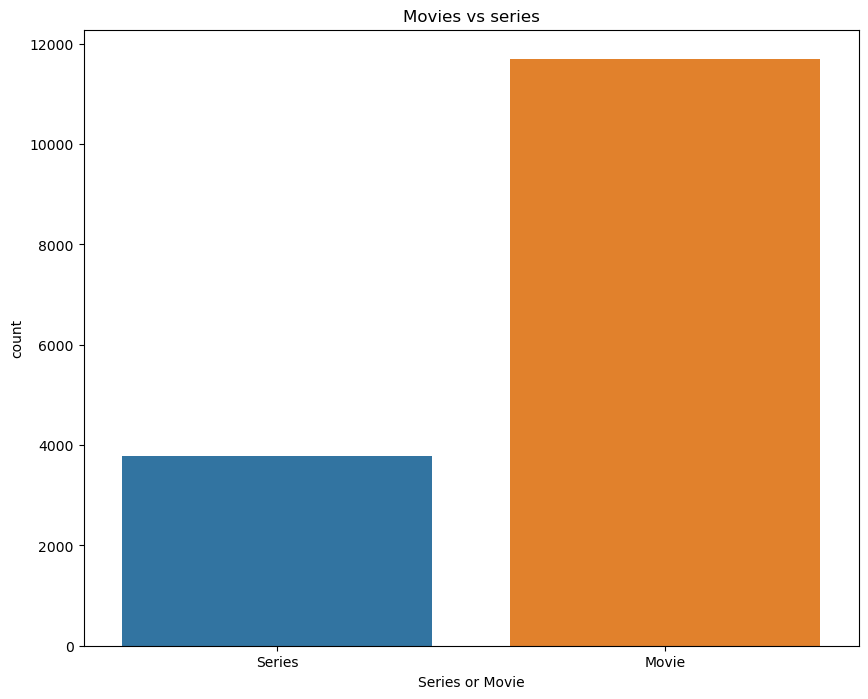

```python
plot.figure(figsize = (10,8))
plot.title("Movies vs series")

sns.countplot(x = df['Series or Movie'])

plot.show()
```

From our data plot above we can see that there are more movies than there are series on Netflix, hence we can assume that they are the popular choice.

We will now move onto our next question.

2. What are the popular genres in movies and series?

For this lets first divide our Dataframe into two different dataframes which are df_movies and df_series

```python
df_movies = df[df['Series or Movie'] == 'Movie']

print("This is the movies dataframe:")
df_movies.head(1)
```

```
This is the movies dataframe:
```

|  | ID | Title | Genre | Tags | Languages | Series or Movie | Hidden Gem Score | Country Availability | Runtime | Director | ... | View Rating | IMDb Score | Rotten Tomatoes Score | Awards Received | Awards Nominated For | Release Date | Netflix Release Date | Summary | IMDb Votes | Image |
| --- | --- | --- | --- | --- | --- | --- | --- | --- | --- | --- | --- | --- | --- | --- | --- | --- | --- | --- | --- | --- | --- |
| 1 | 2 | HOW TO BUILD A GIRL | Comedy | Dramas,Comedies,Films Based on Books,British | English | Movie | 7.0 | Canada | 1-2 hour | Coky Giedroyc | ... | R | 5.8 | 79.0 | 1.0 | NaN | 08 May 2020 | 2021-03-04 | When nerdy Johanna moves to London, things get... | 2838.0 | https://occ-0-1081-999.1.nflxso.net/dnm/api/v6... |

1 rows × 22 columns

```python
df_series = df[df['Series or Movie'] == 'Series']
print("This is the series dataframe:")
df_series.head(1)
```

```
This is the series dataframe:
```

|  | ID | Title | Genre | Tags | Languages | Series or Movie | Hidden Gem Score | Country Availability | Runtime | Director | ... | View Rating | IMDb Score | Rotten Tomatoes Score | Awards Received | Awards Nominated For | Release Date | Netflix Release Date | Summary | IMDb Votes | Image |
| --- | --- | --- | --- | --- | --- | --- | --- | --- | --- | --- | --- | --- | --- | --- | --- | --- | --- | --- | --- | --- | --- |
| 0 | 1 | Lets Fight Ghost | Crime, Drama, Fantasy, Horror, Romance | Comedy Programmes,Romantic TV Comedies,Horror ... | Swedish, Spanish | Series | 4.3 | Thailand | < 30 minutes | Tomas Alfredson | ... | R | 7.9 | 98.0 | 74.0 | 57.0 | 12 Dec 2008 | 2021-03-04 | A med student with a supernatural gift tries t... | 205926.0 | https://occ-0-4708-64.1.nflxso.net/dnm/api/v6/... |

1 rows × 22 columns

When looking on any video streaming service, we see that every video has a genre tagged to inform the viewer on what kind of movie or show they will be watching.

The definition of genre is a category of artistic composition, as in music or literature, characterized by similarities in form, style, or subject matter.

Lets see the differnt types of genres in the "Series" category first.

```python
df_series['Genre'].unique()
```

```
array(['Crime, Drama, Fantasy, Horror, Romance', 'Drama', 'Crime',
       'Animation, Action, Comedy', 'Crime, Drama', 'Drama, Sci-Fi',
       'Comedy, Romance', 'Adventure, Comedy, Drama, Thriller, War',
       'Drama, History, War',
       'Animation, Action, Adventure, Drama, Sci-Fi',
       'Animation, Comedy, Drama', 'Animation, Short', 'Short, Drama',
       'Comedy, Crime', 'Family, Game-Show',
       'Biography, Crime, Drama, Mystery, Thriller',
       'Crime, Drama, Mystery, Thriller', 'Action, Crime, Thriller',
       'Documentary', 'Drama, Romance',
       'Animation, Action, Adventure, Comedy, Family, Fantasy, Sci-Fi',
       'Crime, Fantasy, Horror, Sci-Fi, Thriller', 'Comedy', 'Romance',
       'Family', 'Mystery, Thriller',
       'Comedy, Crime, Drama, Mystery, Thriller', 'Documentary, Sport',
       'Comedy, Drama, Thriller', 'Drama, Music',
       'Action, Fantasy, History', 'Action, Adventure, Drama, Fantasy',
       'Animation, Comedy', 'Action, Adventure, Fantasy, Sci-Fi', 'Short',
       'Comedy, Drama', nan, 'Adventure, Drama, Fantasy, Romance',
       'Animation, Adventure, Fantasy',
       'Animation, Adventure, Comedy, Family, Fantasy, Music',
       'Reality-TV', 'Crime, Drama, Thriller', 'Thriller', 'Animation',
       'Documentary, Crime', 'Animation, Adventure, Comedy', 'Drama, War',
       'Animation, Action, Fantasy, Mystery', 'Animation, Drama, Music',
       'Animation, Adventure, Family, Fantasy', 'Documentary, Comedy',
       'Talk-Show', 'Documentary, Animation',
       'Animation, Action, Adventure, Drama, History',
       'Comedy, Drama, Family, Romance', 'Animation, Action, Sci-Fi',
       'Animation, Action, Music, Romance, Sci-Fi',
       'Comedy, Drama, Fantasy', 'Comedy, Game-Show, Reality-TV',
       'Drama, Fantasy, Sci-Fi, Thriller',
       'Action, Adventure, Fantasy, Horror, Mystery',
       'Animation, Action, Family, Fantasy', 'Animation, Family, Fantasy',
       'Drama, Fantasy, Romance', 'Drama, Mystery',
       'Fantasy, Mystery, Romance', 'Animation, Family',
       'Romance, Drama, Mystery',
       'Animation, Action, Comedy, Family, Sci-Fi',
       'Comedy, Drama, Romance', 'Mystery', 'Sci-Fi', 'Horror',
       'Drama, Adventure', 'Action, Drama, Thriller',
       'Documentary, Reality-TV', 'Adventure, Comedy, Family',
       'Documentary, History', 'Short, Drama, Family',
```

[output cut: 582 more lines]

```
       'Animation, Action, Drama, Family, Fantasy, Horror',
       'Action, Crime, Horror',
       'Animation, Adventure, Comedy, Drama, Family, Fantasy',
       'Animation, Action, Comedy, Family, Fantasy',
       'Animation, Action, Adventure, Comedy, Drama, Fantasy, Romance, Sci-Fi, Thriller',
       'Animation, Action, Comedy, Drama, Family, Fantasy, Sci-Fi',
       'Adventure, Comedy, Drama, Family, Fantasy, Romance',
       'Animation, Adventure, Comedy, Drama, Family, Fantasy, Music, Romance',
       'Drama, Family, Fantasy',
       'Animation, Action, Adventure, Comedy, Family, Fantasy, Western',
       'Action, Adventure, Crime, Drama, Mystery, Sci-Fi',
       'Animation, Action, Adventure, Family, Fantasy, Mystery',
       'Family, Comedy, Music',
       'Animation, Action, Adventure, Fantasy, Sport, Thriller'],
      dtype=object)
```

As can be seen from above there are many different types of genre. We will now make a subset of the top genres to work further on this.

```python
df_series_gen = df_series.dropna(subset=['Genre'])
```

```python
series_gen_list = df_series_gen.Genre.str.split(',')
s_gen_list = {}

# Using loop to create and separate genres
for genres in series_gen_list:
    for genre in genres:
        genre = genre.strip()  # Remove leading and trailing whitespace
        if genre in s_gen_list:
            s_gen_list[genre] += 1
        else:
            s_gen_list[genre] = 1

# Creating DataFrame from the genre counts
s_gen_df = pd.DataFrame(list(s_gen_list.values()), index=s_gen_list.keys(), columns=['Counts of Genres in Tv Series'])
s_gen_df.sort_values(by='Counts of Genres in Tv Series', ascending=False, inplace=True)  # Sort the DataFrame in descending order
top_10_s_gen = s_gen_df[:10]  # Get the top 10 genres

# Print the DataFrame to check its content
print(top_10_s_gen)
```

```
           Counts of Genres in Tv Series
Drama                               1400
Comedy                              1110
Animation                            877
Action                               562
Romance                              561
Fantasy                              537
Adventure                            445
Crime                                436
Thriller                             425
Family                               401
```

Now plot the bar plot

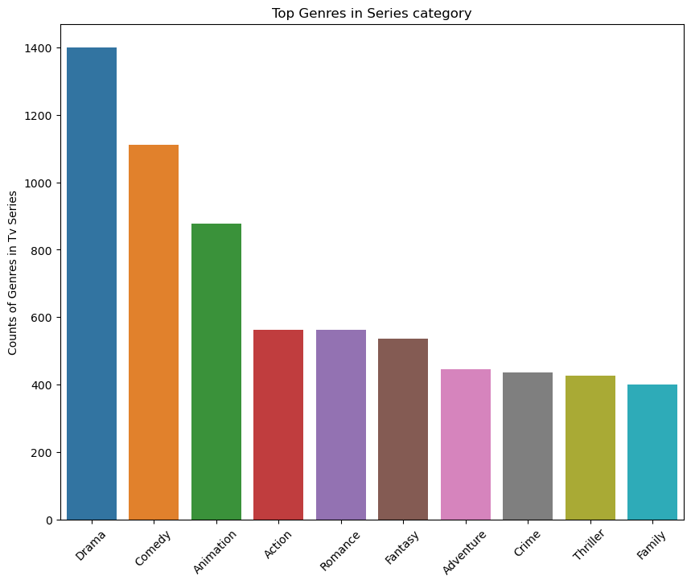

```python
plot.figure(figsize=(10, 8))
plot.title("Top Genres in Series category")
sns.barplot(x=top_10_s_gen.index, y=top_10_s_gen['Counts of Genres in Tv Series'])
plot.xticks(rotation=45)
plot.show()
```

We can see from the above bar plot that the most popular genre for series is Drama.

Let us now conduct the same experiment for the movies subsection.

```python
df_movies['Genre'].unique()
```

```
array(['Comedy', 'Drama, Thriller', 'Animation, Short, Drama', ...,
       'Action, Animation, Comedy, Romance',
       'Action, Crime, Drama, Western',
       'Adventure, Drama, Fantasy, Romance, Thriller'], dtype=object)
```

```python
df_movie_gen = df_movies.dropna(subset=['Genre'])
```

```python
movies_gen_list = df_movie_gen.Genre.str.split(',')
m_gen_list = {}

# Using loop to create and separate genres
for genres in movies_gen_list:
    for genre in genres:
        genre = genre.strip()  # Remove leading and trailing whitespace
        if genre in m_gen_list:
            m_gen_list[genre] += 1
        else:
            m_gen_list[genre] = 1

# Creating DataFrame from the genre counts
m_gen_df = pd.DataFrame(list(m_gen_list.values()), index=m_gen_list.keys(), columns=['Counts of Genres in Movies'])
m_gen_df.sort_values(by='Counts of Genres in Movies', ascending=False, inplace=True)  # Sort the DataFrame in descending order
top_10_m_gen = m_gen_df[:10]  # Get the top 10 genres

# Print the DataFrame to check its content
print(top_10_m_gen)
```

```
           Counts of Genres in Movies
Drama                            4959
Comedy                           3967
Thriller                         2314
Action                           2248
Romance                          1884
Crime                            1496
Adventure                        1364
Fantasy                          1057
Family                           1032
Horror                            884
```

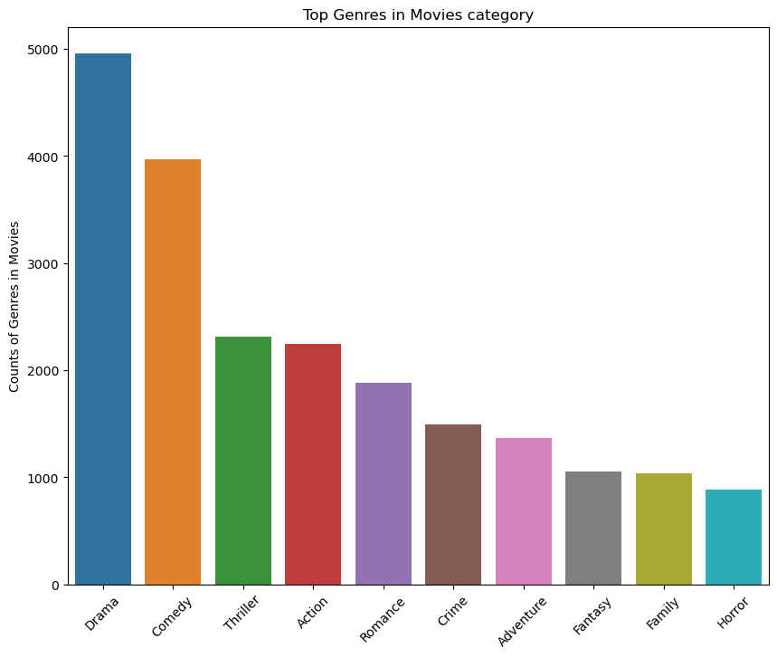

```python
plot.figure(figsize=(10, 8))
plot.title("Top Genres in Movies category")
sns.barplot(x=top_10_m_gen.index, y=top_10_m_gen['Counts of Genres in Movies'])
plot.xticks(rotation=45)
plot.show()
```

Once again we see that Drama is the most popular type of genre.

When choosing a movie or series to watch, people sometimes have a preference on the language that they like to watch in.

3. Let us figure out the most watched languages

Lets first start with movies this time.

```python
df_movies_lang  = df.dropna(subset= ['Languages'])
```

```python
movie_lang_list = df_movies_lang.Languages.str.split(',')

m_lang_list = {}

for languages in movie_lang_list:
    for language in languages:
        language = language.strip()
        if (language in m_lang_list):
            m_lang_list[language]+=1
        else:
            m_lang_list[language]=1

m_lang_df = pd.DataFrame(list(m_lang_list.values()), index=m_lang_list.keys(), columns=['Counts of Languages in Movies'])
m_lang_df.sort_values(by='Counts of Languages in Movies', ascending=False, inplace=True)  # Sort the DataFrame in descending order
top_10_m_lang = m_lang_df[:10]  # Get the top 10 languages

# Print the DataFrame to check its content
print(top_10_m_lang)
```

```
          Counts of Languages in Movies
English                            8041
Japanese                           1667
Spanish                            1143
French                             1055
Korean                              735
German                              682
Hindi                               539
Mandarin                            491
Italian                             484
Russian                             335
```

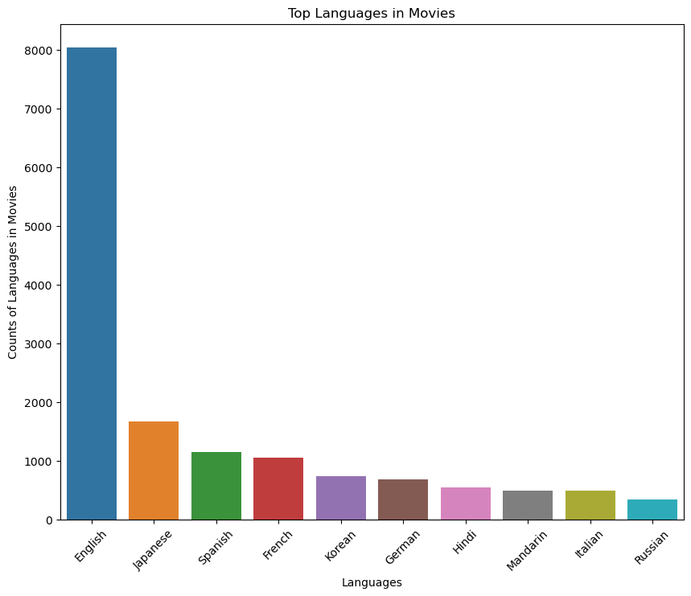

```python
plot.figure(figsize=(10, 8))
plot.title("Top Languages in Movies")
sns.barplot(x=top_10_m_lang.index, y=top_10_m_lang['Counts of Languages in Movies'])
plot.xticks(rotation=45)
plot.ylabel('Counts of Languages in Movies')
plot.xlabel('Languages')
plot.show()
```

Now lets do the same for series.

```python
df_series_lang  = df.dropna(subset= ['Languages'])
```

```python
series_lang_list = df_series_lang.Languages.str.split(',')

s_lang_list = {}

for languages in series_lang_list:
    for language in languages:
        language = language.strip()
        if (language in s_lang_list):
            s_lang_list[language]+=1
        else:
            s_lang_list[language]=1

s_lang_df = pd.DataFrame(list(s_lang_list.values()), index=s_lang_list.keys(), columns=['Counts of Languages in TV Series'])
s_lang_df.sort_values(by='Counts of Languages in TV Series', ascending=False, inplace=True)  # Sort the DataFrame in descending order
top_10_s_lang = s_lang_df[:10]  # Get the top 10 languages

# Print the DataFrame to check its content
print(top_10_s_lang)
```

```
          Counts of Languages in TV Series
English                               8041
Japanese                              1667
Spanish                               1143
French                                1055
Korean                                 735
German                                 682
Hindi                                  539
Mandarin                               491
Italian                                484
Russian                                335
```

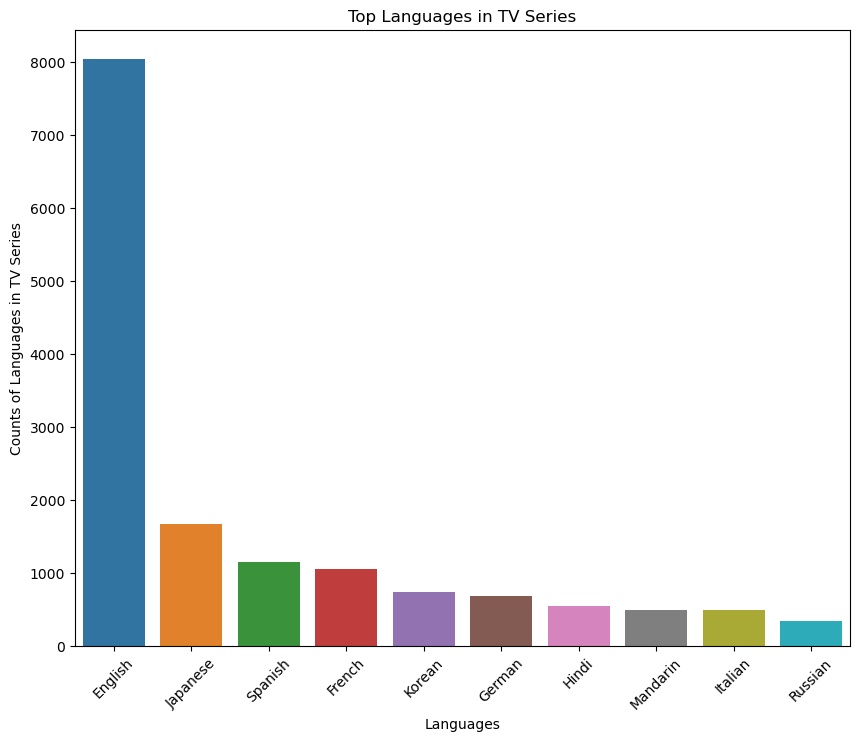

```python
plot.figure(figsize=(10, 8))
plot.title("Top Languages in TV Series")
sns.barplot(x=top_10_s_lang.index, y=top_10_s_lang['Counts of Languages in TV Series'])
plot.xticks(rotation=45)
plot.ylabel('Counts of Languages in TV Series')
plot.xlabel('Languages')
plot.show()
```

Something else people look at when they look at a movie or a series is the IMDb/ Rotten Tomatoes scores.

4. We will now find the most popular TV Series and Movies from IMDb and Rotten Tomatoes.

For those who don't know, IMDb (an acronym for Internet Movie Database) is an online database of information related to films, television series, podcasts, home videos, video games, and streaming content online – including cast, production crew and personal biographies, plot summaries, trivia, ratings, and fan and critical reviews. IMDb began as a fan-operated movie database on the Usenet group "rec.arts.movies" in 1990, and moved to the Web in 1993.

Let us first begin with movies.

```python
df_movie_imdb = df_movies.sort_values(by='IMDb Score',ascending=False)

top_10_movies_imdb = df_movie_imdb[:10]
```

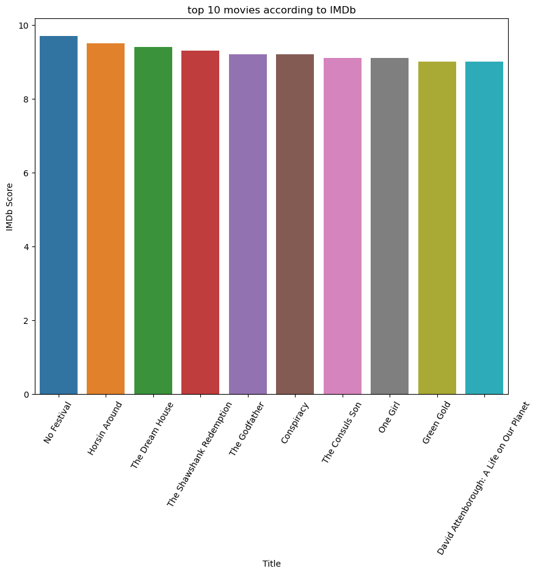

```python
plt.figure(figsize=(10,8))
plt.title("top 10 movies according to IMDb")
plt.xticks(rotation = 60)
sns.barplot(x = top_10_movies_imdb['Title'] , y = top_10_movies_imdb['IMDb Score'])
```

We see that No Festival has the highest score on IMDb. Lets now check series.

```python
df_series_imdb = df_series.sort_values(by='IMDb Score',ascending=False)

top_10_series_imdb = df_series_imdb[:10]
```

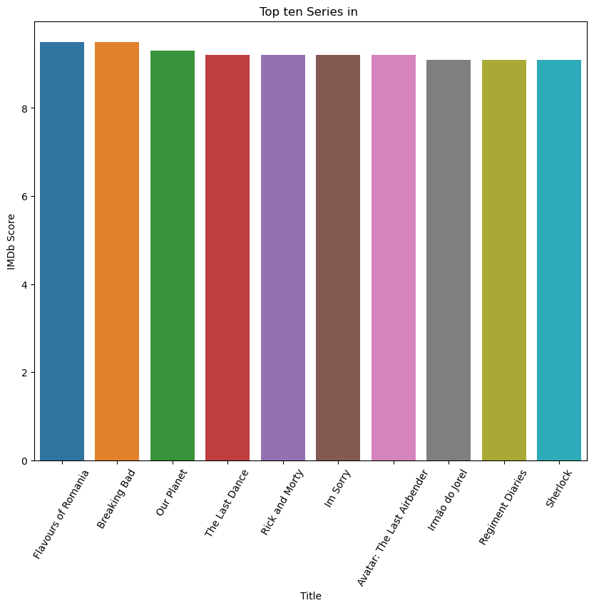

```python
plt.figure(figsize=(10,8))
plt.title("Top ten Series in ")
plt.xticks(rotation = 60)

sns.barplot(x= top_10_series_imdb['Title'],y= top_10_series_imdb['IMDb Score'])
```

We see that the top rated TV series on IMDb are Flavours of Romania and Breaking Bad.

We will now do the same for Rotten Tomatoes.

For those who don't know: Rotten Tomatoes is an American review-aggregation website for film and television. The company was launched in August 1998 by three undergraduate students at the University of California, Berkeley: Senh Duong, Patrick Y. Lee, and Stephen Wang. Although the name "Rotten Tomatoes" connects to the practice of audiences throwing rotten tomatoes in disapproval of a poor stage performance, the direct inspiration for the name from Duong, Lee, and Wang came from an equivalent scene in the 1992 Canadian film Léolo.

Let first do movies

```python
df_movie_rt = df_movies.sort_values(by= 'Rotten Tomatoes Score',ascending=False)

top_10_movies_rt = df_movie_rt[:10]
```

[figure not shown]

```python
plt.figure(figsize=(10,8))
plt.title("Top ten movies according to Rotten Tomatoes ")
plt.xticks(rotation = 65)

sns.barplot(x = top_10_movies_rt['Title'],y = top_10_movies_rt['Rotten Tomatoes Score'])
```

All ten of these movies are highly rated on Rotten Tomatoes. Let us now look at series.

```python
df_series_rt = df_series.dropna(subset=['Rotten Tomatoes Score'])
df_series_rt = df_series_rt.sort_values(by = 'Rotten Tomatoes Score', ascending = False)

top_10_series_rt = df_series_rt[:10]
```

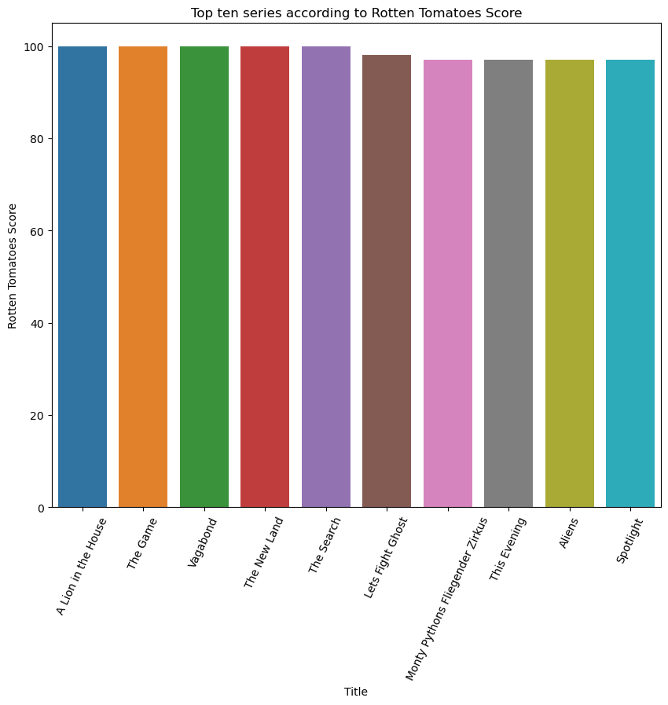

```python
plt.figure(figsize=(10,8))
plt.title("Top ten series according to Rotten Tomatoes Score")
plt.xticks(rotation = 65)

sns.barplot(x= top_10_series_rt['Title'],y = top_10_series_rt['Rotten Tomatoes Score'])
```

On Rotten Tomatoes we see that there is a 5-way tie between A Lion in the House, The Game, Vagabond, The New Land, and The Search.

# Inferences and Conclusions